# Tipología y ciclo de vida de los datos: Práctica 2

Autor: Joan Prieto y Ricardo Martínez

Junio 2021

# 1 Resolución

## 1.1 Descripción del dataset

```r
if (!require('dplyr')) install.packages('dplyr');library('dplyr')
if (!require('tidyr')) install.packages('tidyr'); library('tidyr')
```

```r
if (!require('ggplot2')) install.packages('ggplot2'); library('ggplot2')
if (!require('FSelector')) install.packages('FSelector'); library('FSelector')
datos <- read.csv('cancer.csv',sep =",", stringsAsFactors = FALSE, header = TRUE)
colnames(datos) <- c("id", "diagnosis", "radius_mean", "texture_mean", "perimeter_mean","area_mean", "smoothness_mean", "compactness_mean", "concavity_mean", "concave.points_mean", "symmetry_mean", "fractal_dimension_mean", "radius_se", "texture_se", "perimeter_se", "area_se", "smoothness_se", "compactness_se", "concavity_se", "concave.points_se", "symmetry_se", "fractal_dimension_se", "radius_worst", "texture_worst", "perimeter_worst", "area_worst", "smoothness_worst", "compactness_worst", "concavity_worst", "concave.points_worst", "symmetry_worst", "fractal_dimension_worst")

head(datos)
```

```
##         id diagnosis radius_mean texture_mean perimeter_mean area_mean
## 1   842517         M       20.57        17.77         132.90    1326.0
## 2 84300903         M       19.69        21.25         130.00    1203.0
## 3 84348301         M       11.42        20.38          77.58     386.1
## 4 84358402         M       20.29        14.34         135.10    1297.0
## 5   843786         M       12.45        15.70          82.57     477.1
## 6   844359         M       18.25        19.98         119.60    1040.0
##   smoothness_mean compactness_mean concavity_mean concave.points_mean
## 1         0.08474          0.07864         0.0869             0.07017
## 2         0.10960          0.15990         0.1974             0.12790
## 3         0.14250          0.28390         0.2414             0.10520
## 4         0.10030          0.13280         0.1980             0.10430
## 5         0.12780          0.17000         0.1578             0.08089
## 6         0.09463          0.10900         0.1127             0.07400
##   symmetry_mean fractal_dimension_mean radius_se texture_se perimeter_se
```

[output cut: 34 more lines]

El dataset:

```r
filas <- dim(datos)[1]
columnas <- dim(datos)[2]
cat("Número de filas en el dataset: ", filas,
    "\nNúmero de columnas en el dataset: ", columnas)
```

```
## Número de filas en el dataset:  568
## Número de columnas en el dataset:  32
```

Como podemos observar tenemos suficientes muestras y características para llevar a cabo un análisis y estudio de los datos (e aplicar tecnicas de mienria de datos).

Identificamos los siguientes atributos:

- número de identificación
- Diagnóstico (M = maligno, B = benigno)
- radio (media de las distancias desde el centro hasta los puntos del perímetro)
- textura (desviación estándar de los valores de la escala de grises)
- perímetro
- área
- suavidad (variación local en longitudes de radio)
- compacidad (perímetro ^ 2 / área - 1.0)
- concavidad (severidad de las porciones cóncavas del contorno)
- puntos cóncavos (número de porciones cóncavas del contorno)
- simetría
- dimensión fractal (“aproximación de la línea de costa” - 1)

La media, el error estándar y el “peor” o el mayor (media de los tres valores más grandes) de estas características se han calculado para cada imagen, resultando en 30 funciones. Por ejemplo, el campo 3 es Radio medio, campo 13 es Radio SE, el campo 23 es Peor radio.

Todos los valores de las características están codificados con cuatro dígitos significativos.

## 1.2 Importancia y objetivos de los análisis

Actualmente el cancer de mama es uno de los canceres más extendidos. En la actulidad un 30% de los canceres diagnosticados a las mujeres corresponde a este tipo de canceres. Tambien tenemos que considerar que es el tumor con mayor presencia en el mundo. De ahí el objetivo de conocer y analizar las caracteristicas principales de los tumores que pueden desencandenar en un cancer de mama de caracter maligno. Una vez que podamos identificar las caracteristicas principales de un cancer maligno podremos diagnosticar futuras muestras y dar una orientación rápida y que sirva de apoyo a los médicos.En este tipo de tumores un diagnostico rápido puede reducir drasticamente la mortalidad.

Actualmente disponemos de historicos de datos que nos permiten llevar a cabo desarrollo de modelos de mineria de datos como clustering o clasificación para poder agrupar los diferentes casos y a su vez técnicas como la regresión logistica o KNN para poder pronosticar nuevos casos en función a los datos históricos.

Por lo tanto los objetivos principales serian: a) Conocer como se distribuyen nuestros datos. b) Conocer las caracteristicas que determinan un cancer de mama de caracter maligno. Y finalmente poder pronosticar futuras muestras.

## 1.3 Limpieza de datos

En primer lugar nos gustaria indicar que dos tipos de datos nulos solemos encontrarnos: - MCAR: se tratan de datos faltantes que se distribuyen de manaera aleatoria, es decir, para todas las observaciones la probabilidad de perdida de una variable es igual. Esta perdida no depende de otras variables. - MAR: la probabilidad de la perdida de la observación de una muestra depende la información observada. Podemos enterderlo mejor con un ejemplo, un competidor de salto que cae eliminado en la 3 ronda no tendra puntación para el resto. Por lo tanto son datos faltantes que depende de la muestra y la información observada (deportista, puntuación por ronda.).

En esta etapa tenemos que ver si disponemos de datos nulos:

```r
library(dplyr)
colSums(is.na(datos))
```

```
##                      id               diagnosis             radius_mean
##                       0                       0                       0
##            texture_mean          perimeter_mean               area_mean
##                       0                       0                       0
##         smoothness_mean        compactness_mean          concavity_mean
##                       0                       0                       0
##     concave.points_mean           symmetry_mean  fractal_dimension_mean
##                       0                       0                       0
##               radius_se              texture_se            perimeter_se
##                       0                       0                       0
##                 area_se           smoothness_se          compactness_se
##                       0                       0                       0
##            concavity_se       concave.points_se             symmetry_se
##                       0                       0                       0
##    fractal_dimension_se            radius_worst           texture_worst
##                       0                       0                       0
##         perimeter_worst              area_worst        smoothness_worst
##                       0                       0                       0
##       compactness_worst         concavity_worst    concave.points_worst
##                       0                       0                       0
##          symmetry_worst fractal_dimension_worst
##                       0                       0
```

Podemos ver ahora que no tenemos datos nulos en nuesto conjunto de datos, este apartado se trata sobre el tratamiento de datos nulos, vamos a proceder a estudiar las opciones que tenemos para poder reemplazar posibles datos nulos a futuro en otras variables. Existen varias técnicas o paquetes para imputar los datos nulos en R, en nuestro caso emplearemos 2: -La técnica de KNN. -Paquete Mice.

Para poder llevar a cabo los supuestos de datos nulos, debemos de crear datos nulos en nuestras variables.

```r
datos_limpios <- datos[-33]
any(is.na(datos_limpios))
```

```
## [1] FALSE
```

```r
if (!require("missForest")) install.packages('missForest'); library('missForest')
set.seed(81)
datos_limpios.mis<- prodNA(datos_limpios,noNA=0.1)
summary(datos_limpios.mis)
```

```
##        id             diagnosis          radius_mean      texture_mean
##  Min.   :     8670   Length:568         Min.   : 6.981   Min.   :10.72
##  1st Qu.:   869254   Class :character   1st Qu.:11.680   1st Qu.:16.20
##  Median :   906564   Mode  :character   Median :13.240   Median :18.84
##  Mean   : 29399555                      Mean   :14.061   Mean   :19.31
##  3rd Qu.:  8910720                      3rd Qu.:15.730   3rd Qu.:21.71
##  Max.   :911320502                      Max.   :28.110   Max.   :39.28
##  NA's   :63                             NA's   :67       NA's   :57
##  perimeter_mean     area_mean      smoothness_mean   compactness_mean
##  Min.   : 43.79   Min.   : 143.5   Min.   :0.05263   Min.   :0.01938
##  1st Qu.: 75.04   1st Qu.: 421.0   1st Qu.:0.08599   1st Qu.:0.06374
##  Median : 86.14   Median : 551.7   Median :0.09545   Median :0.09242
##  Mean   : 91.90   Mean   : 652.2   Mean   :0.09612   Mean   :0.10281
##  3rd Qu.:103.70   3rd Qu.: 766.6   3rd Qu.:0.10515   3rd Qu.:0.12980
##  Max.   :188.50   Max.   :2501.0   Max.   :0.16340   Max.   :0.34540
##  NA's   :62       NA's   :47       NA's   :44        NA's   :63
##  concavity_mean    concave.points_mean symmetry_mean    fractal_dimension_mean
##  Min.   :0.00000   Min.   :0.00000     Min.   :0.1060   Min.   :0.05024
##  1st Qu.:0.02964   1st Qu.:0.02012     1st Qu.:0.1618   1st Qu.:0.05768
##  Median :0.06361   Median :0.03370     Median :0.1788   Median :0.06146
##  Mean   :0.09059   Mean   :0.04893     Mean   :0.1808   Mean   :0.06279
##  3rd Qu.:0.13267   3rd Qu.:0.07409     3rd Qu.:0.1957   3rd Qu.:0.06611
##  Max.   :0.42680   Max.   :0.20120     Max.   :0.3040   Max.   :0.09744
##  NA's   :52        NA's   :57          NA's   :51       NA's   :50
##    radius_se        texture_se      perimeter_se       area_se
##  Min.   :0.1115   Min.   :0.3602   Min.   : 0.757   Min.   :  6.802
##  1st Qu.:0.2335   1st Qu.:0.8398   1st Qu.: 1.598   1st Qu.: 17.810
##  Median :0.3197   Median :1.1190   Median : 2.295   Median : 24.250
##  Mean   :0.3990   Mean   :1.2189   Mean   : 2.875   Mean   : 40.002
##  3rd Qu.:0.4709   3rd Qu.:1.4752   3rd Qu.: 3.394   3rd Qu.: 44.960
##  Max.   :2.8730   Max.   :4.8850   Max.   :21.980   Max.   :542.200
##  NA's   :55       NA's   :56       NA's   :54       NA's   :59
##  smoothness_se     compactness_se     concavity_se     concave.points_se
##  Min.   :0.00171   Min.   :0.00225   Min.   :0.00000   Min.   :0.00000
##  1st Qu.:0.00509   1st Qu.:0.01276   1st Qu.:0.01494   1st Qu.:0.00753
##  Median :0.00635   Median :0.02017   Median :0.02592   Median :0.01082
##  Mean   :0.00709   Mean   :0.02527   Mean   :0.03156   Mean   :0.01173
##  3rd Qu.:0.00823   3rd Qu.:0.03179   3rd Qu.:0.04212   3rd Qu.:0.01471
##  Max.   :0.03113   Max.   :0.13540   Max.   :0.39600   Max.   :0.05279
##  NA's   :57        NA's   :51        NA's   :56        NA's   :67
```

[output cut: 9 more lines]

```
##  Min.   : 50.41   Min.   : 223.6   Min.   :0.07117   Min.   :0.02729
##  1st Qu.: 84.39   1st Qu.: 516.5   1st Qu.:0.11650   1st Qu.:0.14195
##  Median : 97.96   Median : 675.0   Median :0.13120   Median :0.20965
##  Mean   :106.90   Mean   : 882.1   Mean   :0.13234   Mean   :0.25136
##  3rd Qu.:124.95   3rd Qu.:1085.0   3rd Qu.:0.14618   3rd Qu.:0.33070
##  Max.   :229.30   Max.   :4254.0   Max.   :0.22260   Max.   :1.05800
##  NA's   :61       NA's   :68       NA's   :48        NA's   :56
##  concavity_worst  concave.points_worst symmetry_worst   fractal_dimension_worst
##  Min.   :0.0000   Min.   :0.00000      Min.   :0.1565   Min.   :0.05504
##  1st Qu.:0.1168   1st Qu.:0.06453      1st Qu.:0.2513   1st Qu.:0.07125
##  Median :0.2275   Median :0.09910      Median :0.2829   Median :0.08019
##  Mean   :0.2731   Mean   :0.11419      Mean   :0.2920   Mean   :0.08408
##  3rd Qu.:0.3862   3rd Qu.:0.16135      3rd Qu.:0.3186   3rd Qu.:0.09210
##  Max.   :1.2520   Max.   :0.29100      Max.   :0.6638   Max.   :0.20750
##  NA's   :52       NA's   :45           NA's   :58       NA's   :61
```

Podemos observar ahora que tenemos datos nulos en todas las variables, como podemos ver todoas las caracteristicas disponen ahora de datos nulos, vamos aplicar la primera técnica, como es de suponer, el ID nunca podrá ser erroneo o faltante ya que de normal, en las bases de datos se trata de un valor autoincrementable, por lo t tanto eliminaremos de nuestos datos este campo para la parte de probar valores nulos:

```r
datos_nulos_prueba <- datos_limpios.mis[-1]
```

##KNN Podemos imputar cualquier tipo de dato, tanto una variable continua como una variable categorica.

```r
if(!require('VIM')) install.packages('VIM'); library('VIM')
```

```
## VIM is ready to use.
```

```
## Suggestions and bug-reports can be submitted at: https://github.com/statistikat/VIM/issues
```

```r
knnOutput <- kNN(datos_nulos_prueba,variable = names(datos_nulos_prueba),k=6)  # perform knn imputation.
summary(knnOutput)
```

```
##   diagnosis          radius_mean      texture_mean   perimeter_mean
##  Length:568         Min.   : 6.981   Min.   :10.72   Min.   : 43.79
##  Class :character   1st Qu.:11.750   1st Qu.:16.34   1st Qu.: 75.20
##  Mode  :character   Median :13.225   Median :18.64   Median : 85.81
##                     Mean   :14.093   Mean   :19.19   Mean   : 91.73
##                     3rd Qu.:15.780   3rd Qu.:21.52   3rd Qu.:103.88
##                     Max.   :28.110   Max.   :39.28   Max.   :188.50
##    area_mean      smoothness_mean   compactness_mean  concavity_mean
##  Min.   : 143.5   Min.   :0.05263   Min.   :0.01938   Min.   :0.00000
##  1st Qu.: 420.3   1st Qu.:0.08649   1st Qu.:0.06623   1st Qu.:0.02976
##  Median : 546.2   Median :0.09532   Median :0.09252   Median :0.05935
##  Mean   : 652.4   Mean   :0.09613   Mean   :0.10310   Mean   :0.08830
##  3rd Qu.: 799.1   3rd Qu.:0.10495   3rd Qu.:0.12995   3rd Qu.:0.13100
##  Max.   :2501.0   Max.   :0.16340   Max.   :0.34540   Max.   :0.42680
##  concave.points_mean symmetry_mean    fractal_dimension_mean   radius_se
##  Min.   :0.00000     Min.   :0.1060   Min.   :0.05024        Min.   :0.1115
##  1st Qu.:0.02008     1st Qu.:0.1621   1st Qu.:0.05821        1st Qu.:0.2349
##  Median :0.03301     Median :0.1792   Median :0.06148        Median :0.3189
##  Mean   :0.04840     Mean   :0.1808   Mean   :0.06268        Mean   :0.3985
##  3rd Qu.:0.07407     3rd Qu.:0.1951   3rd Qu.:0.06581        3rd Qu.:0.4731
##  Max.   :0.20120     Max.   :0.3040   Max.   :0.09744        Max.   :2.8730
##    texture_se      perimeter_se       area_se        smoothness_se
##  Min.   :0.3602   Min.   : 0.757   Min.   :  6.802   Min.   :0.001713
##  1st Qu.:0.8561   1st Qu.: 1.602   1st Qu.: 17.840   1st Qu.:0.005229
##  Median :1.0950   Median : 2.230   Median : 24.065   Median :0.006284
##  Mean   :1.2050   Mean   : 2.824   Mean   : 39.555   Mean   :0.007002
##  3rd Qu.:1.4391   3rd Qu.: 3.304   3rd Qu.: 45.017   3rd Qu.:0.007980
##  Max.   :4.8850   Max.   :21.980   Max.   :542.200   Max.   :0.031130
##  compactness_se      concavity_se     concave.points_se   symmetry_se
##  Min.   :0.002252   Min.   :0.00000   Min.   :0.000000   Min.   :0.007882
##  1st Qu.:0.013262   1st Qu.:0.01506   1st Qu.:0.007917   1st Qu.:0.015215
##  Median :0.020475   Median :0.02517   Median :0.010777   Median :0.018600
##  Mean   :0.025240   Mean   :0.03089   Mean   :0.011663   Mean   :0.020219
##  3rd Qu.:0.031850   3rd Qu.:0.04032   3rd Qu.:0.014505   3rd Qu.:0.022740
##  Max.   :0.135400   Max.   :0.39600   Max.   :0.052790   Max.   :0.061460
##  fractal_dimension_se  radius_worst   texture_worst   perimeter_worst
##  Min.   :0.0008948    Min.   : 7.93   Min.   :12.02   Min.   : 50.41
##  1st Qu.:0.0022057    1st Qu.:13.05   1st Qu.:21.38   1st Qu.: 84.32
##  Median :0.0031035    Median :14.97   Median :25.45   Median : 97.45
##  Mean   :0.0037068    Mean   :16.24   Mean   :25.68   Mean   :107.22
```

[output cut: 64 more lines]

```
##
##  concavity_worst_imp concave.points_worst_imp symmetry_worst_imp
##  Mode :logical       Mode :logical            Mode :logical
##  FALSE:516           FALSE:523                FALSE:510
##  TRUE :52            TRUE :45                 TRUE :58
##
##
##
##  fractal_dimension_worst_imp
##  Mode :logical
##  FALSE:507
##  TRUE :61
##
##
##
```

Como podemos observar se han creado variables logicas que no nos interesan, estas variables que se han generado son la base que emplea para poder imputar los valores nulos en nuestro dataset, por lo tanto tendremos que seleccionar unicamente las variables del dataset original:

```r
knn_dataset <- subset(knnOutput,select =diagnosis:fractal_dimension_worst)
summary(knn_dataset)
```

```
##   diagnosis          radius_mean      texture_mean   perimeter_mean
##  Length:568         Min.   : 6.981   Min.   :10.72   Min.   : 43.79
##  Class :character   1st Qu.:11.750   1st Qu.:16.34   1st Qu.: 75.20
##  Mode  :character   Median :13.225   Median :18.64   Median : 85.81
##                     Mean   :14.093   Mean   :19.19   Mean   : 91.73
##                     3rd Qu.:15.780   3rd Qu.:21.52   3rd Qu.:103.88
##                     Max.   :28.110   Max.   :39.28   Max.   :188.50
##    area_mean      smoothness_mean   compactness_mean  concavity_mean
##  Min.   : 143.5   Min.   :0.05263   Min.   :0.01938   Min.   :0.00000
##  1st Qu.: 420.3   1st Qu.:0.08649   1st Qu.:0.06623   1st Qu.:0.02976
##  Median : 546.2   Median :0.09532   Median :0.09252   Median :0.05935
##  Mean   : 652.4   Mean   :0.09613   Mean   :0.10310   Mean   :0.08830
##  3rd Qu.: 799.1   3rd Qu.:0.10495   3rd Qu.:0.12995   3rd Qu.:0.13100
##  Max.   :2501.0   Max.   :0.16340   Max.   :0.34540   Max.   :0.42680
##  concave.points_mean symmetry_mean    fractal_dimension_mean   radius_se
##  Min.   :0.00000     Min.   :0.1060   Min.   :0.05024        Min.   :0.1115
##  1st Qu.:0.02008     1st Qu.:0.1621   1st Qu.:0.05821        1st Qu.:0.2349
##  Median :0.03301     Median :0.1792   Median :0.06148        Median :0.3189
##  Mean   :0.04840     Mean   :0.1808   Mean   :0.06268        Mean   :0.3985
##  3rd Qu.:0.07407     3rd Qu.:0.1951   3rd Qu.:0.06581        3rd Qu.:0.4731
##  Max.   :0.20120     Max.   :0.3040   Max.   :0.09744        Max.   :2.8730
##    texture_se      perimeter_se       area_se        smoothness_se
##  Min.   :0.3602   Min.   : 0.757   Min.   :  6.802   Min.   :0.001713
##  1st Qu.:0.8561   1st Qu.: 1.602   1st Qu.: 17.840   1st Qu.:0.005229
##  Median :1.0950   Median : 2.230   Median : 24.065   Median :0.006284
##  Mean   :1.2050   Mean   : 2.824   Mean   : 39.555   Mean   :0.007002
##  3rd Qu.:1.4391   3rd Qu.: 3.304   3rd Qu.: 45.017   3rd Qu.:0.007980
##  Max.   :4.8850   Max.   :21.980   Max.   :542.200   Max.   :0.031130
##  compactness_se      concavity_se     concave.points_se   symmetry_se
##  Min.   :0.002252   Min.   :0.00000   Min.   :0.000000   Min.   :0.007882
##  1st Qu.:0.013262   1st Qu.:0.01506   1st Qu.:0.007917   1st Qu.:0.015215
##  Median :0.020475   Median :0.02517   Median :0.010777   Median :0.018600
##  Mean   :0.025240   Mean   :0.03089   Mean   :0.011663   Mean   :0.020219
##  3rd Qu.:0.031850   3rd Qu.:0.04032   3rd Qu.:0.014505   3rd Qu.:0.022740
##  Max.   :0.135400   Max.   :0.39600   Max.   :0.052790   Max.   :0.061460
##  fractal_dimension_se  radius_worst   texture_worst   perimeter_worst
##  Min.   :0.0008948    Min.   : 7.93   Min.   :12.02   Min.   : 50.41
##  1st Qu.:0.0022057    1st Qu.:13.05   1st Qu.:21.38   1st Qu.: 84.32
##  Median :0.0031035    Median :14.97   Median :25.45   Median : 97.45
##  Mean   :0.0037068    Mean   :16.24   Mean   :25.68   Mean   :107.22
##  3rd Qu.:0.0043255    3rd Qu.:18.66   3rd Qu.:29.68   3rd Qu.:126.00
##  Max.   :0.0298400    Max.   :36.04   Max.   :49.54   Max.   :229.30
##    area_worst     smoothness_worst  compactness_worst concavity_worst
##  Min.   : 223.6   Min.   :0.07117   Min.   :0.02729   Min.   :0.0000
##  1st Qu.: 516.5   1st Qu.:0.11720   1st Qu.:0.14758   1st Qu.:0.1168
##  Median : 673.3   Median :0.13140   Median :0.21145   Median :0.2244
##  Mean   : 876.4   Mean   :0.13236   Mean   :0.25169   Mean   :0.2698
##  3rd Qu.:1073.5   3rd Qu.:0.14522   3rd Qu.:0.33322   3rd Qu.:0.3821
##  Max.   :4254.0   Max.   :0.22260   Max.   :1.05800   Max.   :1.2520
##  concave.points_worst symmetry_worst   fractal_dimension_worst
##  Min.   :0.00000      Min.   :0.1565   Min.   :0.05504
##  1st Qu.:0.06497      1st Qu.:0.2527   1st Qu.:0.07143
##  Median :0.09885      Median :0.2829   Median :0.08002
##  Mean   :0.11427      Mean   :0.2912   Mean   :0.08376
##  3rd Qu.:0.16250      3rd Qu.:0.3164   3rd Qu.:0.09141
##  Max.   :0.29100      Max.   :0.6638   Max.   :0.20750
```

Finalmente podemos ver que no tenemos datos nulos y tampoco tenemos la variables que se habian creado de manaera automatica. Terminamos indicando que este metodo es valido tanto para variables númericas continuas como para variables categóricas, este tipo de imputación de datos mejor el error que se genera al imputarlos de manera automatica con la media o la mediana de los datos.

##MICE

Se trata de un imputación multiple. Cada variable se imputa de una manera independiente, para variables númericas continuas mediante (pmm), para variables de datos binarios (regresión logistica , es decir toman dos valores “logreg”), para datos categóricos ordenados (odds proporcional) y para no ordenados ( regresión logística politómica,“polyreg”). vamos a trabajar con las variables numéricas a modo de ejemplo. Para trabajar con los valores categóricos unicamente tendriamos que modificar el tipo de imputación. Seleccionamos dos variables a modo de ejemplo.

```r
if(!require('mice')) install.packages('mice'); library('mice')
datos_categoricos <- datos_limpios.mis["diagnosis"]
datos_numericos <- datos_limpios.mis[3:4]
datos_imputados<- mice(datos_numericos,m=5,maxit =50, method = 'pmm', seed = 500 )
summary(datos_imputados)
```

```
## Class: mids
## Number of multiple imputations:  5
## Imputation methods:
##  radius_mean texture_mean
##        "pmm"        "pmm"
## PredictorMatrix:
##              radius_mean texture_mean
## radius_mean            0            1
## texture_mean           1            0
```

```r
any(is.na(datos_imputados$imp$radius_mean))
```

```
## [1] FALSE
```

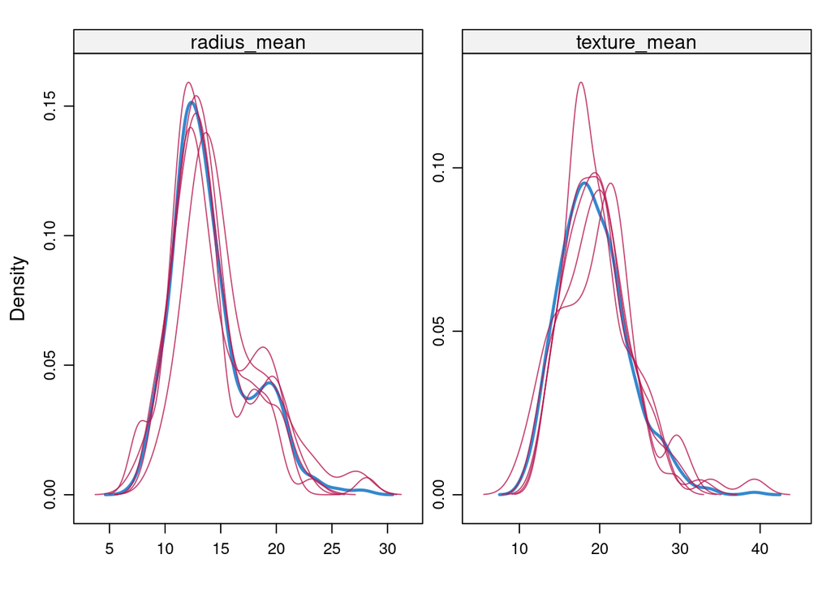

```r
densityplot(datos_imputados)
```

Podemos ver en magenta los valores que se han ido imputando a lo largo de la regresion lineal, vemos que se adaptan de manera correcta a la media de los valores reales de dicha variable.

Tambien podriamos indicar que el método de imputación de valores sea mediante el algoritmo CART:

```r
datos_imputados<- mice(datos_numericos,m=5,maxit =10, method = 'cart', seed = 500 )
```

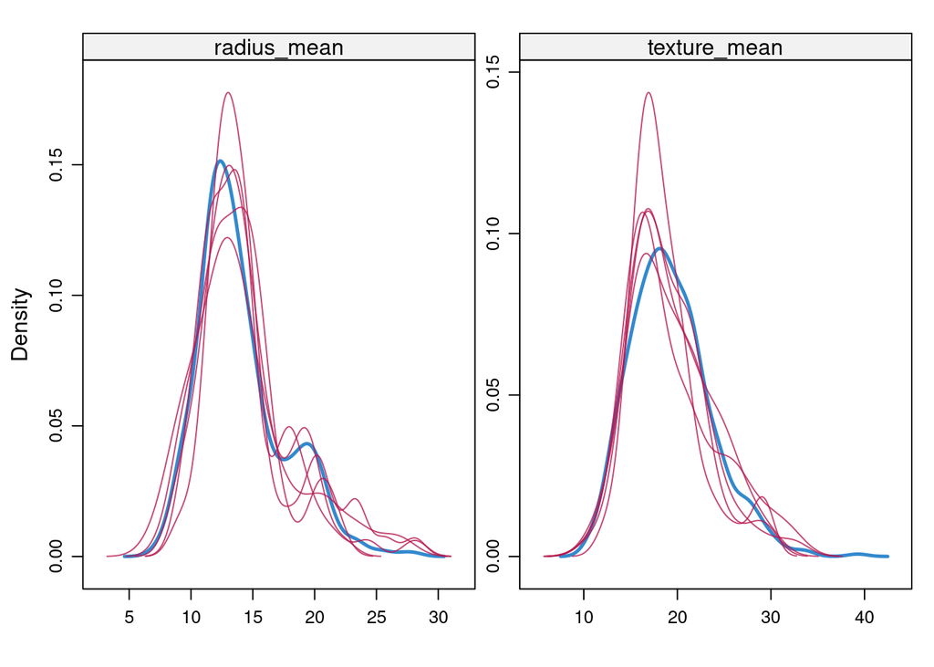

```r
densityplot(datos_imputados)
```

Al cambiar el método de imputación de los valores, vemos como con el método de CART tenemos outliers bastante marcados, esto deberia de analizarse para comprobar a que se deben.

Con estos dos ejemplos de imputación de datos (existen otros métodos pero hemos considerado explicar e implementar dos) vemos como se llevaria a cabo un proceso de imputación de datos nulos.

Como se ha visto con anterioridad, nuestro fichero de origen no tenia datos nulos. A modo de indicar como trabajar con ellos hemos llevado a cabo esta sección.

##Tratamiento de valores extremos.

En este punto nos centraremos en ver y tratar los valores extremos de nuestras variables. Para ello lo haremos sobre las variables principales. En primer lugar llevamos a cabo un escalado de los datos para tenerlos todos en el mismo rango.

```r
datos_escalados <- mutate_if(datos_limpios,is.numeric,scale,center = FALSE)
```

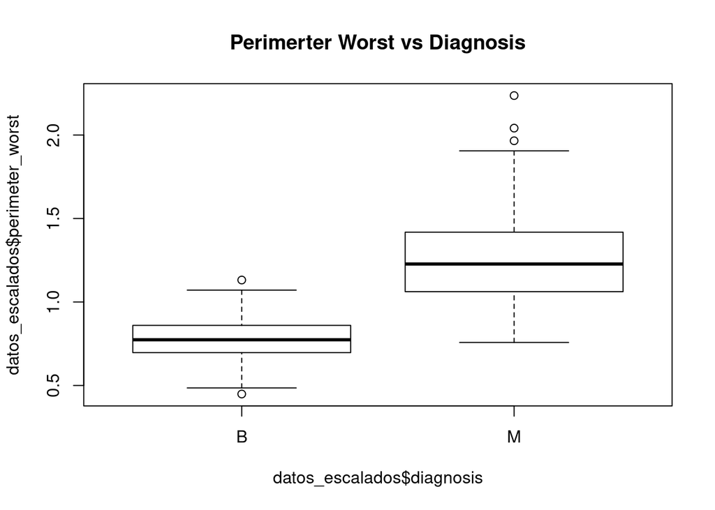

```r
boxplot(datos_escalados$perimeter_worst~datos_escalados$diagnosis,main="Perimerter Worst vs Diagnosis")
```

Observamos claramente como los tumores malignos tienen un mayor perimetro, tambien se ve claramente la presencia de outlieres en ambos tipos, sobre todo y con mayor intensidad en los malignos.